# Temple University, CHEM 3405 - Physical Chemistry of Biomolecules

## Instructor: Dr. Vincent Voelz

### TA: Rob Raddi

**Office:** Beury Hall, Room 102

**Office Hours:** Monday & Wednesday 2-3 pm

**Email:** rraddi@temple.edu

**GitHub:** github.com/robraddi

**Website:** robraddi.github.io

### Homework Expectations

#### Example homework problems:

**1. The wavelength of this laser is 532 nm. Calculate the energy (in Joules) of a photon of this wavelength.**

Recall for general chemistry that Planck's constant $h$ is $6.626\times 10^{-34} J.s.$

$$ E = h\nu = \frac{hc}{\lambda} = \boxed{3.73 x 10^{-19} J}$$

- boxed answer
- correct significant figures
- correct units

**2. a) Wave anatomy: Write down the mathematical form describing a sinusoidal wave $f(x, t)$, annotated with the wavelength $λ$, phase velocity $v$, and amplitude $A$.**

\begin{align*} f(x,t=0) &= Acos(\frac{2\pi}{\lambda}(x-\nu t) + \phi) \\ &= Acos(k(x-\nu t) + \phi) \end{align*}

where $k = 2\pi/\lambda$

**Do you recall how functions are manipulated?**

```python
%matplotlib inline
import numpy as np
import plot as p

def function(x, t, A=1, nu=1, lam=1, phi=0):
    f = np.array([A*np.cos(2*np.pi/lam*(x[i]-nu*t)+phi) for i in range(len(x))])
    return f
```

```python
x = np.linspace(-100,100,100)
```

**2. b) Plot $f(x, t=0)$ with phase shift of $0$,$\frac{\pi}{4}$,$\frac{\pi}{2}$ and $\frac{3\pi}{4}$**

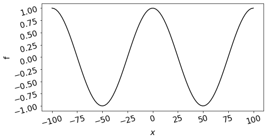

```python
f = function(x, t=0, A=1, nu=1, lam=1, phi=0)
p.simple_plot(x,f,xlabel='$x$',ylabel='f',Type='line',color='k',fig_size=(8,4))
```

\begin{align*} f(x,t=0) &= Acos(\frac{2\pi}{\lambda}(x-\nu t) + \phi) \\ &= Acos(\frac{2\pi}{\lambda}x + \phi) \end{align*}

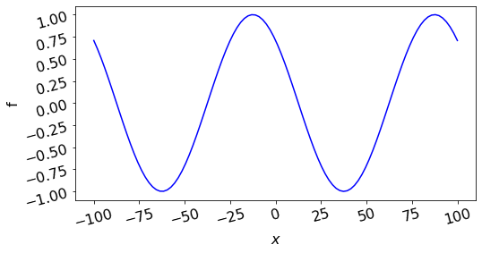

```python
f = function(x, t=0, A=1, nu=1, lam=1, phi=np.pi/4)
p.simple_plot(x,f,xlabel='$x$',ylabel='f',Type='line',color='b',fig_size=(8,4))
```

$$f(x,t=0) = Acos(\frac{2\pi}{\lambda}x + \frac{\pi}{4})$$

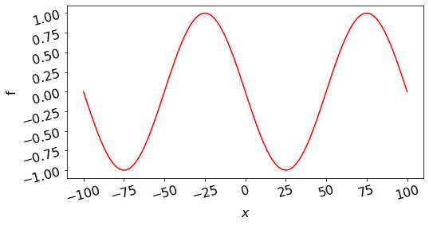

```python
f = function(x, t=0, A=1, nu=1, lam=1, phi=np.pi/2)
p.simple_plot(x,f,xlabel='$x$',ylabel='f',Type='line',color='r',fig_size=(8,4))
```

$$f(x,t=0) = Acos(\frac{2\pi}{\lambda}x + \frac{\pi}{2})$$

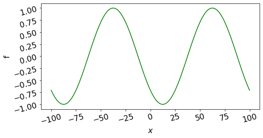

```python
f = function(x, t=0, A=1, nu=1, lam=1, phi=3*np.pi/4)
p.simple_plot(x,f,xlabel='$x$',ylabel='f',Type='line',color='g',fig_size=(8,4))
```

$$f(x,t=0) = Acos(\frac{2\pi}{\lambda}x + \frac{3\pi}{4})$$

#### As $\phi$ increases $f(x)$ will shift left.

**2. b) Plot $f(x, t=0)$ with an amplitude of 2 and a vertical shift of 2.**

\begin{align*} f(x,t=0) &= Acos(\frac{2\pi}{\lambda}(x-\nu t) + \phi) \\ &= Acos(\frac{2\pi}{\lambda}x + \phi) \end{align*}

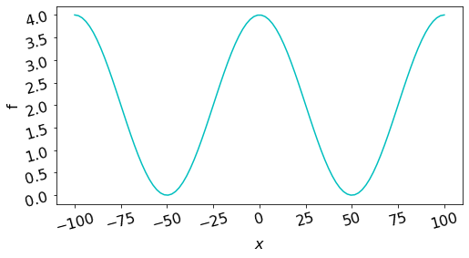

```python
vertical_shift = 2
f = function(x, t=0, A=2, nu=1, lam=1, phi=0)+vertical_shift
p.simple_plot(x,f,xlabel='$x$',ylabel='f',Type='line',color='c',fig_size=(8,4))
```

**2. c) Plot $f(x, t=0)^{2}$**

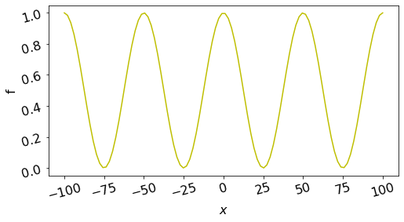

```python
f = function(x, t=0, A=1, nu=1, lam=1, phi=0)**2
p.simple_plot(x,f,xlabel='$x$',ylabel='f',Type='line',color='y',fig_size=(8,4))
```

**3. What is $\frac{\partial f}{\partial x}$?**

Recall:

1) Chain rule

2) $\frac{\partial sin(x)}{\partial x} = cos(x)$ and $\frac{\partial cos(x)}{\partial x} = -sin(x)$

\begin{align*} f(x,t) &= Acos(\frac{2\pi}{\lambda}(x-\nu t) + \phi) \\ \frac{\partial f}{\partial x} &= -\frac{2 \pi}{\lambda} A sin(\frac{2 \pi}{\lambda}(x-\nu t)+\phi) \end{align*}